# Unsupervised machine learning in Sklearn

In this project I use principal component analysis and k-means clustering to visualize data. I wanted to understand and visualize the differences and similarities between sets of data. The dataset I'll be working on is playing card decks scraped from online tournament postings.

```python
import numpy as np
import matplotlib.pyplot as plt
import pandas as pd
import sqlite3
```

```python
con = sqlite3.connect("D:\Documents\Misc\mimicvat_backup_db\CARDINFO.db")
```

```python
pd.set_option('display.max_columns', 500)
df = pd.read_sql_query('SELECT * FROM CARDS',con)
```

```python
df.head()
```

|  | ID | NAME | CMC | MANACOST | POWER | TOUGHNESS | COLOR | CARDSET | TYPE | PICURL | FOIL | NONFOIL | ONLINEONLY | RARITY | RESERVED | TCGPLAYER_ID | CARDMARKET_ID |
| --- | --- | --- | --- | --- | --- | --- | --- | --- | --- | --- | --- | --- | --- | --- | --- | --- | --- |
| 0 | 5ad416dc-4ab6-45b5-9d54-080f5becde60 | Archfiend of Sorrows | 7.0 | {5}{B}{B} | 4 | 5 | ['B'] | j21 | Creature — Demon | https://c1.scryfall.com/file/scryfall-cards/no... | True | True | True | uncommon | False | NaN | NaN |
| 1 | c4df2846-67ba-4228-9e32-fec788f1eab3 | Baffling Defenses | 2.0 | {1}{W} | None | None | ['W'] | j21 | Instant | https://c1.scryfall.com/file/scryfall-cards/no... | True | True | True | common | False | NaN | NaN |
| 2 | 5f52e2aa-59c2-4df2-92ec-15926d61b40f | Boneyard Aberration | 5.0 | {4}{B} | 3 | 3 | ['B'] | j21 | Creature — Skeleton Dog | https://c1.scryfall.com/file/scryfall-cards/no... | True | True | True | common | False | NaN | NaN |
| 3 | 936df148-e8c8-4359-8861-2b8a4abeadc4 | Bounty of the Deep | 3.0 | {2}{U} | None | None | ['U'] | j21 | Sorcery | https://c1.scryfall.com/file/scryfall-cards/no... | True | True | True | uncommon | False | NaN | NaN |
| 4 | a6830e11-2f85-45b0-bd1f-cc66e5aa92c5 | Davriel, Soul Broker | 4.0 | {2}{B}{B} | None | None | ['B'] | j21 | Legendary Planeswalker — Davriel | https://c1.scryfall.com/file/scryfall-cards/no... | True | True | True | mythic | False | NaN | NaN |

```python
df_deck = pd.read_sql_query('SELECT main_deck.uuid, main_deck.cardname, main_deck.quantity FROM MAIN_DECK, deck_meta where main_deck.uuid = deck_meta.uuid and deck_meta.format = "pauper"',con)
```

my deck data is stored in a sql database using a uuid for each deck, the card name, and the quantity of that card in the deck.

```python
df_deck.head(5)
```

|  | uuid | cardname | quantity |
| --- | --- | --- | --- |
| 0 | a588beb8-cc22-11ec-80c8-56000233f66b | Barren Moor | 1.0 |
| 1 | a588beb8-cc22-11ec-80c8-56000233f66b | Piranha Marsh | 1.0 |
| 2 | a588beb8-cc22-11ec-80c8-56000233f66b | Rakdos Carnarium | 2.0 |
| 3 | a588beb8-cc22-11ec-80c8-56000233f66b | Swamp | 14.0 |
| 4 | a588beb8-cc22-11ec-80c8-56000233f66b | Crypt Rats | 2.0 |

```python
df_deck = df_deck.drop(columns=["quantity"])
```

```python
deck_matrix = pd.get_dummies(df_deck, columns=["uuid"])
```

```python
deck_matrix.head()
```

|  | cardname | uuid_003a9bce-cc23-11ec-80c8-56000233f66b | uuid_003a9bcf-cc23-11ec-80c8-56000233f66b | uuid_003a9bd0-cc23-11ec-80c8-56000233f66b | uuid_016a386a-cc23-11ec-80c8-56000233f66b | uuid_016a386b-cc23-11ec-80c8-56000233f66b | uuid_016a386c-cc23-11ec-80c8-56000233f66b | uuid_016a386d-cc23-11ec-80c8-56000233f66b | uuid_02b03788-cc23-11ec-80c8-56000233f66b | uuid_02b03789-cc23-11ec-80c8-56000233f66b | uuid_02b0378a-cc23-11ec-80c8-56000233f66b | uuid_03cecb98-cc23-11ec-80c8-56000233f66b | uuid_03cecb99-cc23-11ec-80c8-56000233f66b | uuid_03cecb9a-cc23-11ec-80c8-56000233f66b | uuid_04f48986-cc23-11ec-80c8-56000233f66b | uuid_04f48987-cc23-11ec-80c8-56000233f66b | uuid_04f48988-cc23-11ec-80c8-56000233f66b | uuid_04f48989-cc23-11ec-80c8-56000233f66b | uuid_066ddc40-cc23-11ec-80c8-56000233f66b | uuid_066ddc41-cc23-11ec-80c8-56000233f66b | uuid_066ddc42-cc23-11ec-80c8-56000233f66b | uuid_074efcac-cc23-11ec-80c8-56000233f66b | uuid_074efcad-cc23-11ec-80c8-56000233f66b | uuid_074efcae-cc23-11ec-80c8-56000233f66b | uuid_074efcaf-cc23-11ec-80c8-56000233f66b | uuid_08ccf7c8-cc23-11ec-80c8-56000233f66b | uuid_08ccf7c9-cc23-11ec-80c8-56000233f66b | uuid_08ccf7ca-cc23-11ec-80c8-56000233f66b | uuid_09d4d6d6-cc23-11ec-80c8-56000233f66b | … |
| --- | --- | --- | --- | --- | --- | --- | --- | --- | --- | --- | --- | --- | --- | --- | --- | --- | --- | --- | --- | --- | --- | --- | --- | --- | --- | --- | --- | --- | --- | --- |
| 0 | Barren Moor | 0 | 0 | 0 | 0 | 0 | 0 | 0 | 0 | 0 | 0 | 0 | 0 | 0 | 0 | 0 | 0 | 0 | 0 | 0 | 0 | 0 | 0 | 0 | 0 | 0 | 0 | 0 | 0 | … |
| 1 | Piranha Marsh | 0 | 0 | 0 | 0 | 0 | 0 | 0 | 0 | 0 | 0 | 0 | 0 | 0 | 0 | 0 | 0 | 0 | 0 | 0 | 0 | 0 | 0 | 0 | 0 | 0 | 0 | 0 | 0 | … |
| 2 | Rakdos Carnarium | 0 | 0 | 0 | 0 | 0 | 0 | 0 | 0 | 0 | 0 | 0 | 0 | 0 | 0 | 0 | 0 | 0 | 0 | 0 | 0 | 0 | 0 | 0 | 0 | 0 | 0 | 0 | 0 | … |
| 3 | Swamp | 0 | 0 | 0 | 0 | 0 | 0 | 0 | 0 | 0 | 0 | 0 | 0 | 0 | 0 | 0 | 0 | 0 | 0 | 0 | 0 | 0 | 0 | 0 | 0 | 0 | 0 | 0 | 0 | … |
| 4 | Crypt Rats | 0 | 0 | 0 | 0 | 0 | 0 | 0 | 0 | 0 | 0 | 0 | 0 | 0 | 0 | 0 | 0 | 0 | 0 | 0 | 0 | 0 | 0 | 0 | 0 | 0 | 0 | 0 | 0 | … |

5 rows × 640 columns

```python
deck_matrix.nunique()
```

```
cardname                                     746
uuid_003a9bce-cc23-11ec-80c8-56000233f66b      2
uuid_003a9bcf-cc23-11ec-80c8-56000233f66b      2
uuid_003a9bd0-cc23-11ec-80c8-56000233f66b      2
uuid_016a386a-cc23-11ec-80c8-56000233f66b      2
                                            ...
uuid_fdf5a8b0-cc22-11ec-80c8-56000233f66b      2
uuid_fefcd52e-cc22-11ec-80c8-56000233f66b      2
uuid_fefcd52f-cc22-11ec-80c8-56000233f66b      2
uuid_fefcd530-cc22-11ec-80c8-56000233f66b      2
uuid_fefcd531-cc22-11ec-80c8-56000233f66b      2
Length: 640, dtype: int64
```

```python
df_deck.nunique()
```

```
uuid        639
cardname    746
dtype: int64
```

```python
deck_matrix = deck_matrix.set_index('cardname')
```

```python
deck_matrix.head()
```

| cardname | uuid_003a9bce-cc23-11ec-80c8-56000233f66b | uuid_003a9bcf-cc23-11ec-80c8-56000233f66b | uuid_003a9bd0-cc23-11ec-80c8-56000233f66b | uuid_016a386a-cc23-11ec-80c8-56000233f66b | uuid_016a386b-cc23-11ec-80c8-56000233f66b | uuid_016a386c-cc23-11ec-80c8-56000233f66b | uuid_016a386d-cc23-11ec-80c8-56000233f66b | uuid_02b03788-cc23-11ec-80c8-56000233f66b | uuid_02b03789-cc23-11ec-80c8-56000233f66b | uuid_02b0378a-cc23-11ec-80c8-56000233f66b | uuid_03cecb98-cc23-11ec-80c8-56000233f66b | uuid_03cecb99-cc23-11ec-80c8-56000233f66b | uuid_03cecb9a-cc23-11ec-80c8-56000233f66b | uuid_04f48986-cc23-11ec-80c8-56000233f66b | uuid_04f48987-cc23-11ec-80c8-56000233f66b | uuid_04f48988-cc23-11ec-80c8-56000233f66b | uuid_04f48989-cc23-11ec-80c8-56000233f66b | uuid_066ddc40-cc23-11ec-80c8-56000233f66b | uuid_066ddc41-cc23-11ec-80c8-56000233f66b | uuid_066ddc42-cc23-11ec-80c8-56000233f66b | uuid_074efcac-cc23-11ec-80c8-56000233f66b | uuid_074efcad-cc23-11ec-80c8-56000233f66b | uuid_074efcae-cc23-11ec-80c8-56000233f66b | uuid_074efcaf-cc23-11ec-80c8-56000233f66b | uuid_08ccf7c8-cc23-11ec-80c8-56000233f66b | uuid_08ccf7c9-cc23-11ec-80c8-56000233f66b | uuid_08ccf7ca-cc23-11ec-80c8-56000233f66b | uuid_09d4d6d6-cc23-11ec-80c8-56000233f66b | uuid_09d4d6d7-cc23-11ec-80c8-56000233f66b | … |
| --- | --- | --- | --- | --- | --- | --- | --- | --- | --- | --- | --- | --- | --- | --- | --- | --- | --- | --- | --- | --- | --- | --- | --- | --- | --- | --- | --- | --- | --- | --- |
| Barren Moor | 0 | 0 | 0 | 0 | 0 | 0 | 0 | 0 | 0 | 0 | 0 | 0 | 0 | 0 | 0 | 0 | 0 | 0 | 0 | 0 | 0 | 0 | 0 | 0 | 0 | 0 | 0 | 0 | 0 | … |
| Piranha Marsh | 0 | 0 | 0 | 0 | 0 | 0 | 0 | 0 | 0 | 0 | 0 | 0 | 0 | 0 | 0 | 0 | 0 | 0 | 0 | 0 | 0 | 0 | 0 | 0 | 0 | 0 | 0 | 0 | 0 | … |
| Rakdos Carnarium | 0 | 0 | 0 | 0 | 0 | 0 | 0 | 0 | 0 | 0 | 0 | 0 | 0 | 0 | 0 | 0 | 0 | 0 | 0 | 0 | 0 | 0 | 0 | 0 | 0 | 0 | 0 | 0 | 0 | … |
| Swamp | 0 | 0 | 0 | 0 | 0 | 0 | 0 | 0 | 0 | 0 | 0 | 0 | 0 | 0 | 0 | 0 | 0 | 0 | 0 | 0 | 0 | 0 | 0 | 0 | 0 | 0 | 0 | 0 | 0 | … |
| Crypt Rats | 0 | 0 | 0 | 0 | 0 | 0 | 0 | 0 | 0 | 0 | 0 | 0 | 0 | 0 | 0 | 0 | 0 | 0 | 0 | 0 | 0 | 0 | 0 | 0 | 0 | 0 | 0 | 0 | 0 | … |

5 rows × 639 columns

```python
from sklearn.decomposition import PCA
from sklearn import preprocessing
```

```python
pca = PCA()
dm = deck_matrix
```

```python
dm.nunique()
```

```
uuid_003a9bce-cc23-11ec-80c8-56000233f66b    2
uuid_003a9bcf-cc23-11ec-80c8-56000233f66b    2
uuid_003a9bd0-cc23-11ec-80c8-56000233f66b    2
uuid_016a386a-cc23-11ec-80c8-56000233f66b    2
uuid_016a386b-cc23-11ec-80c8-56000233f66b    2
                                            ..
uuid_fdf5a8b0-cc22-11ec-80c8-56000233f66b    2
uuid_fefcd52e-cc22-11ec-80c8-56000233f66b    2
uuid_fefcd52f-cc22-11ec-80c8-56000233f66b    2
uuid_fefcd530-cc22-11ec-80c8-56000233f66b    2
uuid_fefcd531-cc22-11ec-80c8-56000233f66b    2
Length: 639, dtype: int64
```

```python
deck_matrix.isnull().values.any()
```

```
False
```

```python
dm.shape
```

```
(11567, 639)
```

```python
dm = dm.groupby('cardname').sum()
```

```python
dm.shape
```

```
(746, 639)
```

```python
dm.head()
```

| cardname | uuid_003a9bce-cc23-11ec-80c8-56000233f66b | uuid_003a9bcf-cc23-11ec-80c8-56000233f66b | uuid_003a9bd0-cc23-11ec-80c8-56000233f66b | uuid_016a386a-cc23-11ec-80c8-56000233f66b | uuid_016a386b-cc23-11ec-80c8-56000233f66b | uuid_016a386c-cc23-11ec-80c8-56000233f66b | uuid_016a386d-cc23-11ec-80c8-56000233f66b | uuid_02b03788-cc23-11ec-80c8-56000233f66b | uuid_02b03789-cc23-11ec-80c8-56000233f66b | uuid_02b0378a-cc23-11ec-80c8-56000233f66b | uuid_03cecb98-cc23-11ec-80c8-56000233f66b | uuid_03cecb99-cc23-11ec-80c8-56000233f66b | uuid_03cecb9a-cc23-11ec-80c8-56000233f66b | uuid_04f48986-cc23-11ec-80c8-56000233f66b | uuid_04f48987-cc23-11ec-80c8-56000233f66b | uuid_04f48988-cc23-11ec-80c8-56000233f66b | uuid_04f48989-cc23-11ec-80c8-56000233f66b | uuid_066ddc40-cc23-11ec-80c8-56000233f66b | uuid_066ddc41-cc23-11ec-80c8-56000233f66b | uuid_066ddc42-cc23-11ec-80c8-56000233f66b | uuid_074efcac-cc23-11ec-80c8-56000233f66b | uuid_074efcad-cc23-11ec-80c8-56000233f66b | uuid_074efcae-cc23-11ec-80c8-56000233f66b | uuid_074efcaf-cc23-11ec-80c8-56000233f66b | uuid_08ccf7c8-cc23-11ec-80c8-56000233f66b | uuid_08ccf7c9-cc23-11ec-80c8-56000233f66b | uuid_08ccf7ca-cc23-11ec-80c8-56000233f66b | uuid_09d4d6d6-cc23-11ec-80c8-56000233f66b | uuid_09d4d6d7-cc23-11ec-80c8-56000233f66b | … |
| --- | --- | --- | --- | --- | --- | --- | --- | --- | --- | --- | --- | --- | --- | --- | --- | --- | --- | --- | --- | --- | --- | --- | --- | --- | --- | --- | --- | --- | --- | --- |
| Abrade | 0 | 0 | 0 | 0 | 0 | 0 | 0 | 0 | 0 | 0 | 0 | 0 | 0 | 0 | 0 | 0 | 0 | 0 | 0 | 0 | 0 | 0 | 0 | 0 | 0 | 0 | 0 | 0 | 0 | … |
| Abundant Growth | 0 | 0 | 0 | 0 | 0 | 0 | 0 | 0 | 0 | 0 | 0 | 0 | 0 | 0 | 0 | 0 | 0 | 0 | 0 | 0 | 0 | 0 | 1 | 0 | 0 | 0 | 0 | 0 | 0 | … |
| Abundant Harvest | 0 | 0 | 0 | 0 | 0 | 0 | 0 | 0 | 0 | 0 | 0 | 0 | 0 | 0 | 0 | 0 | 0 | 0 | 0 | 0 | 0 | 0 | 0 | 0 | 0 | 0 | 0 | 0 | 0 | … |
| Accumulated Knowledge | 0 | 0 | 0 | 0 | 0 | 0 | 0 | 0 | 0 | 0 | 0 | 0 | 0 | 0 | 0 | 0 | 0 | 0 | 0 | 0 | 0 | 0 | 0 | 0 | 0 | 0 | 0 | 0 | 0 | … |
| Aethersnipe | 0 | 0 | 0 | 0 | 0 | 0 | 0 | 0 | 0 | 0 | 0 | 0 | 0 | 0 | 0 | 0 | 0 | 0 | 0 | 0 | 0 | 0 | 0 | 0 | 0 | 0 | 0 | 0 | 0 | … |

5 rows × 639 columns

```python
dm = dm.transpose()
```

I compiled a numpy array comparing each deck and each card in each deck with a boolean value of its presence. For simplicities sake i'm ignoring the quantity.

```python
dm.head()
```

| cardname | Abrade | Abundant Growth | Abundant Harvest | Accumulated Knowledge | Aethersnipe | Agony Warp | Akki War Paint | Akroan Crusader | Akroan Skyguard | Alms of the Vein | Alpine Meadow | Ancestral Anger | Ancestral Blade | Ancestral Mask | Ancient Den | Ancient Stirrings | Angelic Renewal | Annoyed Altisaur | Anticipate | Apostle's Blessing | Arbor Elf | Arcane Denial | Arcbound Tracker | Archaeomancer | Architects of Will | Arctic Treeline | Ardent Elementalist | Ardent Recruit | Armadillo Cloak | … |
| --- | --- | --- | --- | --- | --- | --- | --- | --- | --- | --- | --- | --- | --- | --- | --- | --- | --- | --- | --- | --- | --- | --- | --- | --- | --- | --- | --- | --- | --- | --- |
| uuid_003a9bce-cc23-11ec-80c8-56000233f66b | 0 | 0 | 0 | 0 | 0 | 0 | 0 | 0 | 0 | 0 | 0 | 0 | 0 | 0 | 0 | 0 | 0 | 0 | 0 | 0 | 0 | 0 | 0 | 1 | 0 | 0 | 0 | 0 | 0 | … |
| uuid_003a9bcf-cc23-11ec-80c8-56000233f66b | 0 | 0 | 0 | 0 | 0 | 0 | 0 | 0 | 0 | 0 | 0 | 0 | 0 | 0 | 0 | 0 | 0 | 0 | 0 | 1 | 0 | 0 | 0 | 0 | 0 | 0 | 0 | 0 | 0 | … |
| uuid_003a9bd0-cc23-11ec-80c8-56000233f66b | 0 | 0 | 0 | 0 | 0 | 0 | 0 | 0 | 0 | 0 | 0 | 0 | 0 | 0 | 0 | 0 | 0 | 0 | 0 | 0 | 0 | 0 | 0 | 0 | 0 | 0 | 0 | 0 | 0 | … |
| uuid_016a386a-cc23-11ec-80c8-56000233f66b | 0 | 0 | 0 | 0 | 0 | 0 | 0 | 0 | 1 | 0 | 0 | 0 | 0 | 0 | 0 | 0 | 0 | 0 | 0 | 1 | 0 | 0 | 0 | 0 | 0 | 0 | 0 | 0 | 0 | … |
| uuid_016a386b-cc23-11ec-80c8-56000233f66b | 0 | 0 | 0 | 0 | 0 | 0 | 0 | 0 | 0 | 0 | 0 | 0 | 0 | 0 | 0 | 0 | 0 | 0 | 0 | 0 | 0 | 0 | 0 | 0 | 0 | 0 | 0 | 0 | 0 | … |

5 rows × 746 columns

```python
dm.index.name
```

```python
pca.fit(dm)
```

```
PCA()
```

```python
dm.index.name
```

```python
cardnames = dm.columns
```

```python
dm.shape
```

```
(639, 746)
```

```python
card_name = dm.index.values
```

```python
card_name
```

[output not shown]

[output cut: 584 more lines]

[output not shown]

```python
pca_data = pca.transform(dm)
```

## Dimensionality reduction

As it stands, my array contains 746 individual cards. To create a visualizion, I need to first reduce the number of dimensions. Sklearn's PCA feature looks at the matrix provided, and reduces the dimensions of the data by compressing that dataset and finding "directions of maximum variance." In plain english, PCA finds subsections of the data which most contribute to variance in the data. For this project I end up graphing the first three principal components in matplotlib, in 3D.

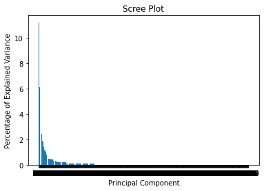

```python
per_var = np.round(pca.explained_variance_ratio_* 100, decimals=1)
labels = ['PC' + str(x) for x in range(1, len(per_var)+1)]

plt.bar(x=range(1,len(per_var)+1), height=per_var, tick_label=labels)
plt.ylabel('Percentage of Explained Variance')
plt.xlabel('Principal Component')
plt.title('Scree Plot')
plt.show()
```

## Visualization

[figure not shown]

```python
pca_df = pd.DataFrame(pca_data, columns=labels)

plt.figure(figsize = (20, 20), dpi = 300)
#plt.add_subplot(projection="3d")
plt.scatter(pca_df.PC1, pca_df.PC2)
plt.title('My PCA Graph')
plt.xlabel('PC1 - {0}%'.format(per_var[0]))
plt.ylabel('PC2 - {0}%'.format(per_var[1]))

#applys uuid to points

#for sample in range(0, len(pca_df.index)):
#    plt.annotate(dm.index[sample], (pca_df.PC1.loc[sample], pca_df.PC2.loc[sample]))

plt.show()
```

This is my first 3d graph of the dataset.

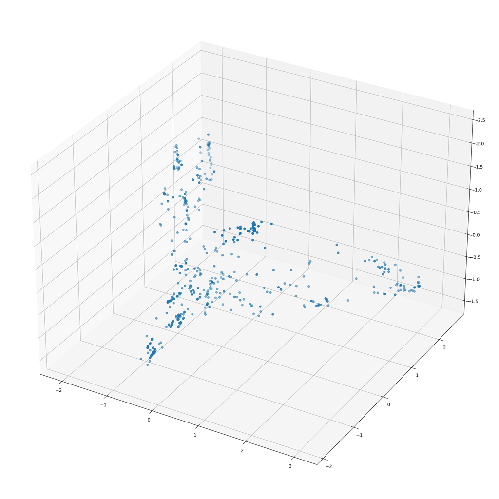

```python
pca_df = pd.DataFrame(pca_data, columns=labels)

fig = plt.figure(figsize = (20, 20), dpi = 300)
ax = fig.add_subplot(projection="3d")

ax.scatter(pca_df.PC1, pca_df.PC2, pca_df.PC3)

#applys uuid to points

#for sample in range(0, len(pca_df.index)):
#    plt.annotate(dm.index[sample], (pca_df.PC1.loc[sample], pca_df.PC2.loc[sample]))

plt.show()
```

```python
from sklearn.cluster import KMeans
```

```python
x = np.array([[pca_df.PC1[i], pca_df.PC2[i], pca_df.PC3[i]] for i in range(len(pca_df.PC1))])
```

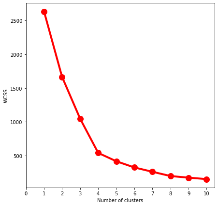

```python
WCSS = []
for i in range(1,11):
    model = KMeans(n_clusters = i,init = 'k-means++')
    model.fit(x)
    WCSS.append(model.inertia_)
fig = plt.figure(figsize = (7,7))
plt.plot(range(1,11),WCSS, linewidth=4, markersize=12,marker='o',color = 'red')
plt.xticks(np.arange(11))
plt.xlabel("Number of clusters")
plt.ylabel("WCSS")
plt.show()
```

```python
model = KMeans(n_clusters = 5, init = "k-means++", max_iter = 300, n_init = 10, random_state = 0)
y_clusters = model.fit_predict(x)
```

## K-means clustering

To cluster the data into different archtypes, I used k-means clustering. This is a method of segmenting data, like the name implies, to find a fixed(k) number of homogenous subgroups.

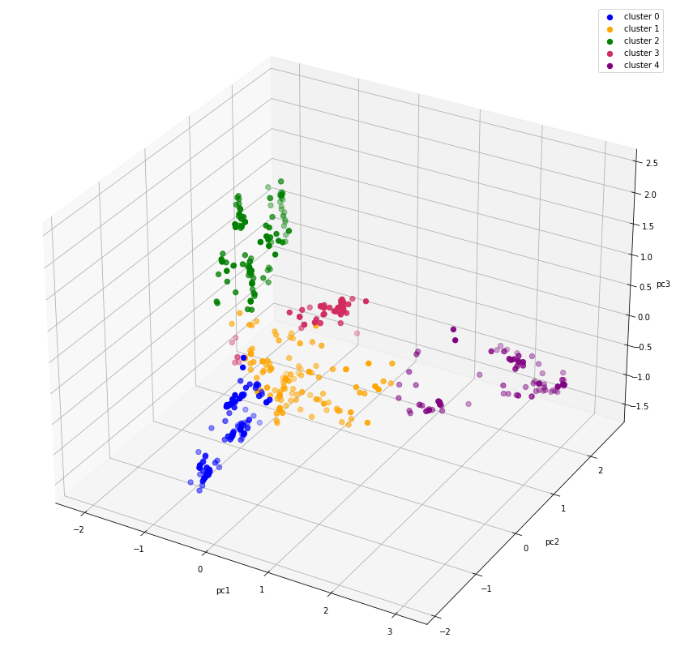

```python
fig = plt.figure(figsize = (15,15))
ax = fig.add_subplot(111, projection='3d')
ax.scatter(x[y_clusters == 0,0],x[y_clusters == 0,1],x[y_clusters == 0,2], s = 40 , color = 'blue', label = "cluster 0")
ax.scatter(x[y_clusters == 1,0],x[y_clusters == 1,1],x[y_clusters == 1,2], s = 40 , color = 'orange', label = "cluster 1")
ax.scatter(x[y_clusters == 2,0],x[y_clusters == 2,1],x[y_clusters == 2,2], s = 40 , color = 'green', label = "cluster 2")
ax.scatter(x[y_clusters == 3,0],x[y_clusters == 3,1],x[y_clusters == 3,2], s = 40 , color = '#D12B60', label = "cluster 3")
ax.scatter(x[y_clusters == 4,0],x[y_clusters == 4,1],x[y_clusters == 4,2], s = 40 , color = 'purple', label = "cluster 4")
ax.set_xlabel('pc1')
ax.set_ylabel('pc2')
ax.set_zlabel('pc3')
ax.legend()
plt.show()
```